# Assignment- Clustering

Akanksha Utreja(11910056)

July 6, 2018

## Individual Assignment 1

1. Marketing to Frequent Fliers. The file EastWestAirlinesCluster.xls (available on the textbook website http://dataminingbook.com/) contains information on 4,000 passengers who belong to an airline’s frequent flier program. For each passenger, the data include information on their mileage history and on different ways they accrued or spent miles in the last year. The goal is to try to identify clusters of passengers that have similar characteristics for the purpose of targeting different segments for different types of mileage offers.
1. Do you need to normalize the data before applying any clustering technique? Why or why not?

Ans. Yes, we need to normalize the data before applying any clustering algorithm because we have miles, days and cc_miles (categorical data). Since, they have different measurement units and Euclidean distance is determined by the scale of different measurements so to remove any bias in the Euclidean distance, we need to standardize it.

2. Apply hierarchical clustering with Euclidean distance and Ward’s method. How many clusters do appear?

In the below dendogram, if we cut at 120 then we get 2 custers. If we cut at 100, then we get 3 clusters so it is dependent on the business problem how many clusters are ideal.

```r
## Libraries
library("dummies")
library("dendextend")
library("gridExtra")
library("cluster")
library("factoextra")
library("MASS")
library("fpc")
```

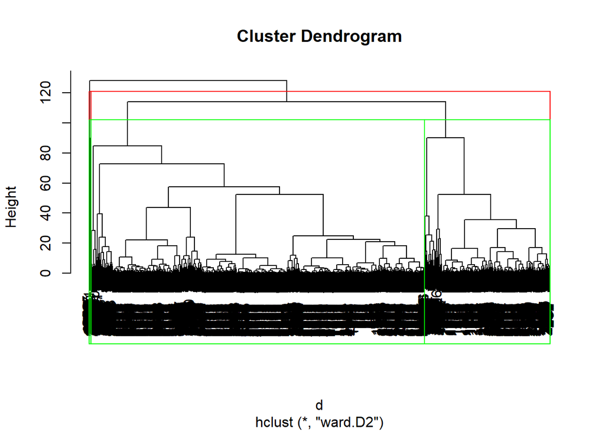

```r
#Setting the working directory,

setwd('C:/Users/AKANKSHA/Desktop/ISB CBA/Data Mining')

#Reading the second sheet of EastWestAirlinesCluster,
input     <- read.csv("EastWestAirlinesCluster.csv",header=TRUE)

#Excluding the ID column,
datawonormal  <- input[,2:11]

# Normalising the data before applying Clustering to give equal importance to all attributes,

#1. Normalizing the categorical data by conevrting to dummy variables,

normalized_data    <- dummy.data.frame(datawonormal, names = "cc1_miles", omit.constants=FALSE )
normalized_data    <- dummy.data.frame(datawonormal, names = "cc2_miles", omit.constants=FALSE )
normalized_data    <- dummy.data.frame(datawonormal, names = "cc3_miles", omit.constants=FALSE )

# Standardizing data,
normalized_data   <- scale(normalized_data)

#Applying the approach of Euclidean distance and Ward's method,

d<- dist(normalized_data, method = "euclidean")

# Hierarchical clustering using Ward's method
fit<- hclust(d, method = "ward.D2" )
plot(fit)
rect.hclust(fit, k=2, border="red")
rect.hclust(fit, k=3, border="green")
```

3. Compare cluster centroids to characterize different clusters and try to give each cluster a label-a meaningful name that characterizes the cluster.

```r
# Cutting into 3 clusters and viewing the clusters,

groups <- cutree(fit, k=3) # cut tree into 3 clusters
membership<-as.matrix(groups)
#membership
cluster1 <- subset(input,membership[,1]==1)
#cluster1
cluster2 <- subset(input,membership[,1]==2)
#cluster2
cluster3 <- subset(input,membership[,1]==3)
#cluster3

#Looking at how the summary looks like,
summary(cluster3)
```

```
##       ID.          Balance         Qual_miles        cc1_miles
##  Min.   : 109   Min.   : 15835   Min.   :   0.00   Min.   :1.000
##  1st Qu.: 948   1st Qu.: 70595   1st Qu.:   0.00   1st Qu.:2.250
##  Median :1914   Median :102354   Median :   0.00   Median :4.000
##  Mean   :1742   Mean   :129951   Mean   :  65.67   Mean   :3.389
##  3rd Qu.:2362   3rd Qu.:127945   3rd Qu.:   0.00   3rd Qu.:4.750
##  Max.   :3361   Max.   :737514   Max.   :1182.00   Max.   :5.000
##    cc2_miles   cc3_miles      Bonus_miles      Bonus_trans
##  Min.   :1   Min.   :2.000   Min.   : 19140   Min.   : 7.00
##  1st Qu.:1   1st Qu.:3.000   1st Qu.: 53832   1st Qu.:19.00
##  Median :1   Median :4.000   Median : 85550   Median :27.50
##  Mean   :1   Mean   :3.722   Mean   : 86260   Mean   :26.22
##  3rd Qu.:1   3rd Qu.:4.750   3rd Qu.:104858   3rd Qu.:32.00
##  Max.   :1   Max.   :5.000   Max.   :217006   Max.   :44.00
##  Flight_miles_12mo Flight_trans_12 Days_since_enroll     Award.
##  Min.   :   0.0    Min.   :0.000   Min.   :1054      Min.   :0.0
##  1st Qu.:   0.0    1st Qu.:0.000   1st Qu.:3596      1st Qu.:0.0
##  Median :   0.0    Median :0.000   Median :4034      Median :0.5
##  Mean   : 422.2    Mean   :1.333   Mean   :4489      Mean   :0.5
##  3rd Qu.: 575.0    3rd Qu.:1.750   3rd Qu.:5811      3rd Qu.:1.0
##  Max.   :2300.0    Max.   :9.000   Max.   :7101      Max.   :1.0
```

```r
# Comparing the centroids,

d <- dist(normalized_data, method = "euclidean")
fit <- hclust(d, method="complete")

groups <- cutree(fit, k=3)

findcenteroid = function(i, dat, groups) {
  ind = (groups == i)
  colMeans(dat[ind,])
}
sapply(unique(groups), findcenteroid, datawonormal, groups)
```

```
##                           [,1]      [,2]      [,3]
## Balance           73547.288828 115682.00 89401.333
## Qual_miles          144.071142    295.50     0.000
## cc1_miles             2.057114      3.75     3.000
## cc2_miles             1.014529      1.00     1.000
## cc3_miles             1.009519      3.00     2.000
## Bonus_miles       17064.150802  74597.50 47920.000
## Bonus_trans          11.576653     32.75    17.000
## Flight_miles_12mo   460.035822    825.00     0.000
## Flight_trans_12       1.373246      2.75     0.000
## Days_since_enroll  4117.809118   5058.75  3863.333
```

Chracterizing the above,

# Cluster 1- Medium class fliers or Economy class fliers

# Cluster 2- High Class Loyal Fliers

# Cluster 3- Non Frequent Travellers

4. To check the stability of clusters, remove a random 5% of the data (by taking a random sample of 95% of the records), and repeat the analysis. Does the same picture emerge?

```r
OriginalDend   <- as.dendrogram(fit)

#Random Sample1 with 95% of data
input_sample=input[sample(nrow(datawonormal),replace=F,size=0.95*nrow(input)),]

d       <- dist(input_sample, method = "euclidean")
fit2 <- hclust(d, method = "ward.D2" )
SampledDendo   <- as.dendrogram(fit2)


## Viewing the dendograms to see how they are similar or different,
OriginalDend
```

```
## 'dendrogram' with 2 branches and 3999 members total, at height 48.68604
```

```r
SampledDendo
```

```
## 'dendrogram' with 2 branches and 3799 members total, at height 6458151
```

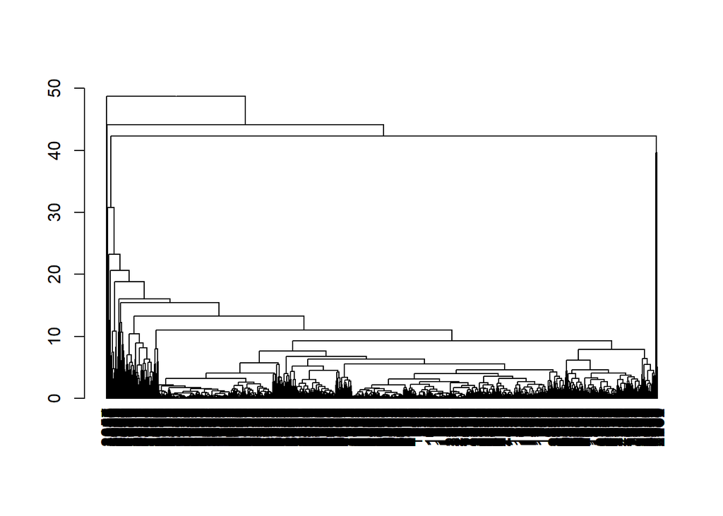

```r
plot(OriginalDend)
```

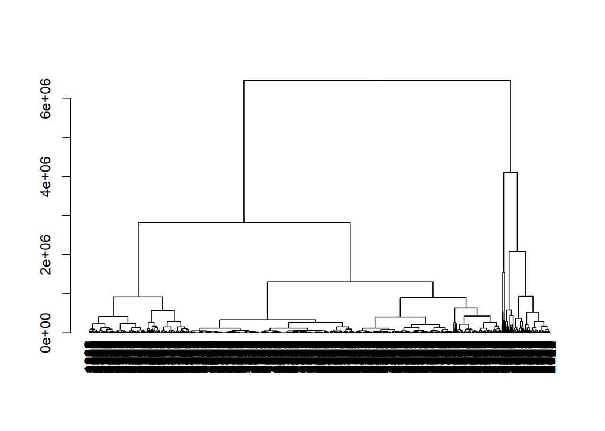

```r
plot(SampledDendo)
```

- From the above we can see that the clusters formed after sampling are different.
5. Cluster all passengers again using k-means clustering. How many clusters do you want to go with? How did you decide on the number of clusters? Explain your choice on the number of clusters.

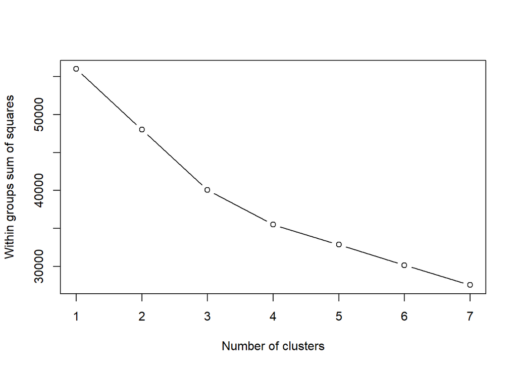

```r
## Determine number of clusters
Cluster_Variability <- matrix(nrow=7, ncol=1)
for (i in 1:7) Cluster_Variability[i] <- kmeans(normalized_data,centers=i, nstart=6)$tot.withinss
plot(1:7, Cluster_Variability, type="b", xlab="Number of clusters", ylab="Within groups sum of squares") ## Elbow curve or Scree plot
```

Clustering all the passeners using k means now,

```r
fit_kmeans <- kmeans(normalized_data, centers=3, iter.max=10, nstart=4)
fit_kmeans$centers
```

```
##      Balance   Qual_miles  cc1_miles   cc2_miles  cc3_miles1  cc3_miles2
## 1  1.3352424  0.738532079  0.3126918  0.17088676 -1.71334165  0.69815475
## 2 -0.3007757 -0.042014499 -0.6585381  0.03826298  0.06723352 -0.02739641
## 3  0.3983928 -0.005325803  1.1606559 -0.08832066  0.06723352 -0.02739641
##   cc3_miles3  cc3_miles4  cc3_miles5 Bonus_miles Bonus_trans
## 1  0.8062606  0.98771075  0.90153954   1.1824371   1.8412346
## 2 -0.0316386 -0.03875892 -0.03537746  -0.5349696  -0.5193389
## 3 -0.0316386 -0.03875892 -0.03537746   0.8403157   0.7391758
##   Flight_miles_12mo Flight_trans_12 Days_since_enroll
## 1        3.40296640      3.69885114         0.3266517
## 2       -0.15782589     -0.17297942        -0.2027709
## 3       -0.08945274     -0.09463393         0.3319314
```

6. How do the characteristics of the clusters, obtained in Part (e), contrast or validate the finding in Part c above?

```r
sapply(unique(groups), findcenteroid, datawonormal, groups)
```

```
##                           [,1]      [,2]      [,3]
## Balance           73547.288828 115682.00 89401.333
## Qual_miles          144.071142    295.50     0.000
## cc1_miles             2.057114      3.75     3.000
## cc2_miles             1.014529      1.00     1.000
## cc3_miles             1.009519      3.00     2.000
## Bonus_miles       17064.150802  74597.50 47920.000
## Bonus_trans          11.576653     32.75    17.000
## Flight_miles_12mo   460.035822    825.00     0.000
## Flight_trans_12       1.373246      2.75     0.000
## Days_since_enroll  4117.809118   5058.75  3863.333
```

```r
fit2 <- kmeans(datawonormal, centers=3, iter.max=10)
fit2$centers
```

```
##     Balance Qual_miles cc1_miles cc2_miles cc3_miles Bonus_miles
## 1 167615.27   266.6037  3.010000  1.008750  1.027500    33942.18
## 2 563233.22   451.9259  3.222222  1.037037  1.037037    53100.85
## 3  36759.97   104.6905  1.785439  1.015394  1.007697    11901.00
##   Bonus_trans Flight_miles_12mo Flight_trans_12 Days_since_enroll
## 1   17.235000          915.1500       2.6725000          4935.159
## 2   20.444444         1758.1235       5.7037037          6203.753
## 3    9.926876          309.5686       0.9278384          3854.871
```

From the above we can say that both the clustering algorithms are providing different results.

7. Which cluster(s) would you target for offers, and what type of offers would you target to customers in that cluster? Include proper reasoning in support of your choice of the cluster(s) and the corresponding offer(s)

```r
fit2$size
```

```
## [1]  800   81 3118
```

From the above we can say that we have more people in Cluster 1 and 3 so we should be targetting those clusters. For Cluster 3, we should offer better discounts like more bonus miles so that they keep using our services. For Cluster 1, we should try and retain these customers by offering cheap deals and more Bonus miles.

# Wine Data Analysis

Step 1: Download the Wine data from the UCI machine learning repository.

Step 2: Do a Principal Components Analysis (PCA) on the data. Please include (copy-paste) the relevant software outputs in your submission while answering the following questions.

1. Enumerate the insights you gathered during your PCA exercise. Please do not clutter your report with too many insignificant insights as it will dilute the value of your other significant findings.

```r
setwd('C:/Users/AKANKSHA/Desktop/ISB CBA/Data Mining')
## Principal Component Analysis

input <- read.csv('C:\\Users\\AKANKSHA\\Desktop\\ISB CBA\\Data Mining\\wine.data', header = TRUE,row.names=NULL)
winedata   <- input[1:178,2:14]
winepca <- princomp(na.omit(winedata), cor = TRUE, scores = TRUE, covmat = NULL)
summary(winepca)
```

```
## Importance of components:
##                           Comp.1    Comp.2    Comp.3    Comp.4     Comp.5
## Standard deviation     2.1692972 1.5801816 1.2025273 0.9586313 0.92370351
## Proportion of Variance 0.3619885 0.1920749 0.1112363 0.0706903 0.06563294
## Cumulative Proportion  0.3619885 0.5540634 0.6652997 0.7359900 0.80162293
##                            Comp.6     Comp.7     Comp.8     Comp.9
## Standard deviation     0.80103498 0.74231281 0.59033665 0.53747553
## Proportion of Variance 0.04935823 0.04238679 0.02680749 0.02222153
## Cumulative Proportion  0.85098116 0.89336795 0.92017544 0.94239698
##                           Comp.10    Comp.11    Comp.12     Comp.13
## Standard deviation     0.50090167 0.47517222 0.41081655 0.321524394
## Proportion of Variance 0.01930019 0.01736836 0.01298233 0.007952149
## Cumulative Proportion  0.96169717 0.97906553 0.99204785 1.000000000
```

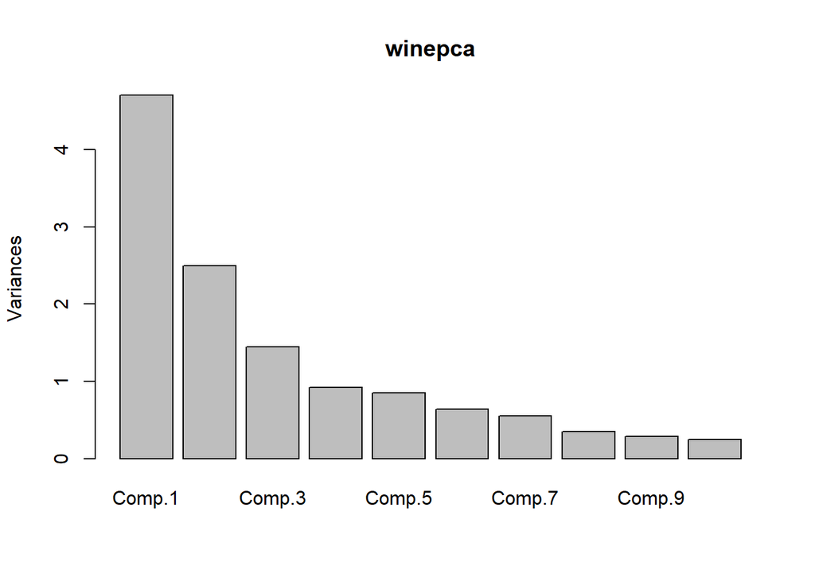

```r
plot(winepca)
```

# Insights

From we can see from the summary statstics that almost 80% of the data can be captured up till column 5.

We can also see from the barplot that the variances are high upto 5 components. So, from the above we can say that 5 components should be taken for the analysis.

2. What are the social and/or business values of those insights, and how the value of those insights can be harnessed???enumerate actionable recommendations for the identified stakeholder in this analysis?

```r
summary(winepca, loading = TRUE)
```

```
## Importance of components:
##                           Comp.1    Comp.2    Comp.3    Comp.4     Comp.5
## Standard deviation     2.1692972 1.5801816 1.2025273 0.9586313 0.92370351
## Proportion of Variance 0.3619885 0.1920749 0.1112363 0.0706903 0.06563294
## Cumulative Proportion  0.3619885 0.5540634 0.6652997 0.7359900 0.80162293
##                            Comp.6     Comp.7     Comp.8     Comp.9
## Standard deviation     0.80103498 0.74231281 0.59033665 0.53747553
## Proportion of Variance 0.04935823 0.04238679 0.02680749 0.02222153
## Cumulative Proportion  0.85098116 0.89336795 0.92017544 0.94239698
##                           Comp.10    Comp.11    Comp.12     Comp.13
## Standard deviation     0.50090167 0.47517222 0.41081655 0.321524394
## Proportion of Variance 0.01930019 0.01736836 0.01298233 0.007952149
## Cumulative Proportion  0.96169717 0.97906553 0.99204785 1.000000000
##
## Loadings:
##         Comp.1 Comp.2 Comp.3 Comp.4 Comp.5 Comp.6 Comp.7 Comp.8 Comp.9
## Alc      0.144  0.484  0.207         0.266  0.214         0.396  0.509
## Mal_ac  -0.245  0.225        -0.537         0.537 -0.421
## Ash             0.316 -0.626  0.214  0.143  0.154  0.149 -0.170 -0.308
## Al_ash  -0.239        -0.612               -0.101  0.287  0.428  0.200
## Mag      0.142  0.300 -0.131  0.352 -0.727        -0.323 -0.156  0.271
## To_phe   0.395        -0.146 -0.198  0.149               -0.406  0.286
## Flav     0.423        -0.151 -0.152  0.109               -0.187
## Non_fla -0.299        -0.170  0.203  0.501 -0.259 -0.595 -0.233  0.196
## phe      0.313        -0.149 -0.399 -0.137 -0.534 -0.372  0.368 -0.209
## Proa            0.530  0.137               -0.419  0.228
## Col_int  0.297 -0.279         0.428  0.174  0.106 -0.232  0.437
## OD280    0.376 -0.164 -0.166 -0.184  0.101  0.266                0.137
## Proline  0.287  0.365  0.127  0.232  0.158  0.120         0.120 -0.576
##         Comp.10 Comp.11 Comp.12 Comp.13
## Alc      0.212   0.226   0.266
## Mal_ac  -0.309          -0.122
## Ash              0.499          -0.141
## Al_ash          -0.479
## Mag
## To_phe  -0.320  -0.304   0.304  -0.464
## Flav    -0.163                   0.832
## Non_fla  0.216  -0.117           0.114
## phe      0.134   0.237          -0.117
## Proa    -0.291          -0.604
## Col_int -0.522          -0.259
## OD280    0.524          -0.601  -0.157
## Proline  0.162  -0.539
```

```r
#loadings(winepca)
```

In general, if the correlation value is near to or greater than 0.5 then it is considered important and worth considering.

Step 3: Do a cluster analysis you may try different algorithms or approaches and go with the one that you find most appropriate using (i) all chemical measurements (ii) using two most significant PC scores.

3. Any more insights you come across during the clustering exercise?

Appying k-means algorithm on the dataset, first we will decide what should be the ideal number of clusters with the help of the plot.

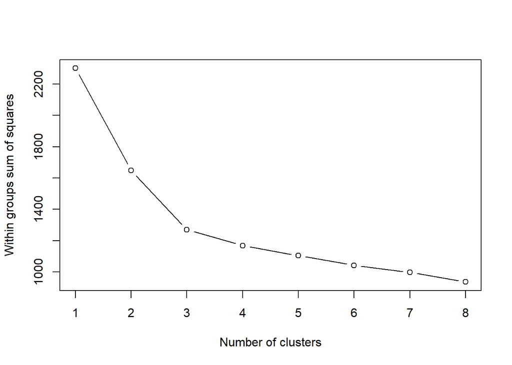

```r
normalized_data <- scale(winedata)
Cluster_Variab <- matrix(nrow=8, ncol=1)
for (i in 1:8) Cluster_Variab[i] <- kmeans(normalized_data, centers=i)$tot.withinss
plot(1:8, Cluster_Variab, type="b", xlab="Number of clusters", ylab="Within groups sum of squares")
```

So, from the above 3 seems like a feasible solution, applying k-means with 3 clusters.

```r
fitwine <- kmeans(normalized_data, centers=3, iter.max=10)

fitwine$size
```

```
## [1] 62 51 65
```

```r
fitwine$centers
```

```
##          Alc     Mal_ac        Ash     Al_ash         Mag      To_phe
## 1  0.8328826 -0.3029551  0.3636801 -0.6084749  0.57596208  0.88274724
## 2  0.1644436  0.8690954  0.1863726  0.5228924 -0.07526047 -0.97657548
## 3 -0.9234669 -0.3929331 -0.4931257  0.1701220 -0.49032869 -0.07576891
##          Flav     Non_fla         phe       Proa    Col_int      OD280
## 1  0.97506900 -0.56050853  0.57865427  0.1705823  0.4726504  0.7770551
## 2 -1.21182921  0.72402116 -0.77751312  0.9388902 -1.1615122 -1.2887761
## 3  0.02075402 -0.03343924  0.05810161 -0.8993770  0.4605046  0.2700025
##      Proline
## 1  1.1220202
## 2 -0.4059428
## 3 -0.7517257
```

```r
t(fitwine$centers)
```

```
##                  1           2           3
## Alc      0.8328826  0.16444359 -0.92346686
## Mal_ac  -0.3029551  0.86909545 -0.39293312
## Ash      0.3636801  0.18637259 -0.49312571
## Al_ash  -0.6084749  0.52289244  0.17012195
## Mag      0.5759621 -0.07526047 -0.49032869
## To_phe   0.8827472 -0.97657548 -0.07576891
## Flav     0.9750690 -1.21182921  0.02075402
## Non_fla -0.5605085  0.72402116 -0.03343924
## phe      0.5786543 -0.77751312  0.05810161
## Proa     0.1705823  0.93889024 -0.89937699
## Col_int  0.4726504 -1.16151216  0.46050459
## OD280    0.7770551 -1.28877614  0.27000254
## Proline  1.1220202 -0.40594284 -0.75172566
```

-> Now, let’s plot the centers to get a better picture of what’s happening.

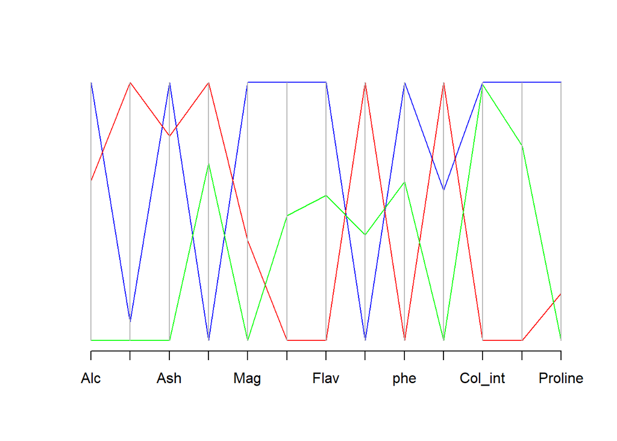

```r
library(MASS)
parcoord(fitwine$centers, c('blue', 'red', 'green'))
```

4. Are there clearly separable clusters of wines? How many clusters did you go with? How the clusters obtained in part (i) are different from or similar to clusters obtained in part (ii), qualitatively

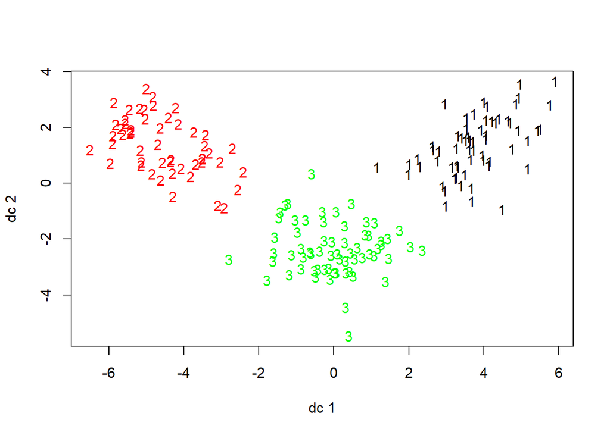

```r
library("fpc")
plotcluster(normalized_data, fitwine$cluster)
```

From the above plot, we can say that they are seperable in 3 clusters. The results are decided using the fpc library and plotting clusters.

5. Could you suggest a subset of the chemical measurements that can separate wines more distinctly? How did you go about choosing that subset? How do the rest of the measurements that were not included while clustering, vary across those clusters?

Ans. –>Subset of Chemical measurements that seperate wines more distinctly:

The measurements which have higher variance help in sepearting the wine more distinctly. In our case, Alchohol, Magnesium, Flavanoids, Color_Intensity, Hue, OD280_OD315 and Proline will help in seperatig the wines more distinctly.

–>How did you choose the subset? Based on the variation, PCA and k-means we can identify the subset.

–>How do the rest of the measurements that were not included while clustering, vary across those clusters?

# Refrences

1.Data Mining Book https://mineracaodedados.files.wordpress.com/2012/07/data-mining-in-excel.pdf

2.Nice Plots http://www.r-bloggers.com/using-r-to-replicate-common-spss-multiple-regression-output/

3.K-Means https://en.wikipedia.org/wiki/K-means_clustering

4.Dendogarms https://cran.r-project.org/web/packages/dendextend/vignettes/introduction.html

5.PCA https://cran.r-project.org/web/packages/HSAUR/vignettes/Ch_principal_components_analysis.pdf